# chapter09_part01_image_segmentation

This is a companion notebook for the book [Deep Learning with Python, Second Edition](https://www.manning.com/books/deep-learning-with-python-second-edition?a_aid=keras&a_bid=76564dff). For readability, it only contains runnable code blocks and section titles, and omits everything else in the book: text paragraphs, figures, and pseudocode.

**If you want to be able to follow what's going on, I recommend reading the notebook side by side with your copy of the book.**

This notebook was generated for TensorFlow 2.6.

SEMANTIC SEGMENTATION USE CASE IS IMPLEMENTED VIA THIS PYTHON CODE.

IT is used in autonomous vehicles and also in images to find patterns and defects say in clothes.

LabelImg is a free, open source tool for graphically labeling images. It's written in Python and uses QT for its graphical interface. It's an easy, free way to label a few hundred images to try out your next object detection project.This is uesd to take any image and create mask for it.

segmentation- color each and every pixel with a different color. for example-humans are colored in brown, cycle in green and background is black. SEMENTATION IS CREATE THE IMAGE MASK FOR THE IMAGE.

# Advanced deep learning for computer vision

# New Section

## Three essential computer vision tasks

## An image segmentation example

```python
'''!wget http://www.robots.ox.ac.uk/~vgg/data/pets/data/images.tar.gz
!wget http://www.robots.ox.ac.uk/~vgg/data/pets/data/annotations.tar.gz
!tar -xf images.tar.gz
!tar -xf annotations.tar.gz '''
```

```
'!wget http://www.robots.ox.ac.uk/~vgg/data/pets/data/images.tar.gz\n!wget http://www.robots.ox.ac.uk/~vgg/data/pets/data/annotations.tar.gz\n!tar -xf images.tar.gz\n!tar -xf annotations.tar.gz '
```

```python
from google.colab import drive
drive.mount('/content/drive')
```

```python
cp '/content/drive/MyDrive/Colab_Notebooks/SECONDYEAR_TRIMESTER4_Module03_deep-learning-applications/DAY4_APPLICATION_OF_DEEP_LEARNING/Semantic_segmentation/images1.tar.gz'  '/content'
```

```python
cp '/content/drive/MyDrive/Colab_Notebooks/SECONDYEAR_TRIMESTER4_Module03_deep-learning-applications/DAY4_APPLICATION_OF_DEEP_LEARNING/Semantic_segmentation/annotations1.tar.gz' '/content'
```

```python
!tar -xf annotations1.tar.gz
!tar -xf images1.tar.gz
```

```python
import os

input_dir = "images/"
target_dir = "annotations/trimaps/"

input_img_paths = sorted(
    [os.path.join(input_dir, fname)
     for fname in os.listdir(input_dir)
     if fname.endswith(".jpg")])
target_paths = sorted(
    [os.path.join(target_dir, fname)
     for fname in os.listdir(target_dir)
     if fname.endswith(".png") and not fname.startswith(".")])
```

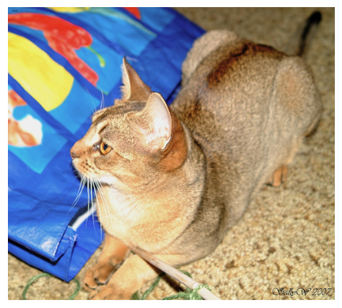

```python
import matplotlib.pyplot as plt
from tensorflow.keras.utils import load_img, img_to_array

plt.axis("off")
plt.imshow(load_img(input_img_paths[9]))
```

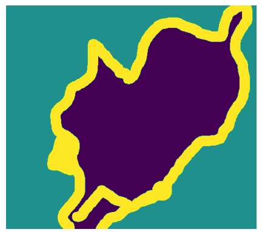

```python
def display_target(target_array):
    normalized_array = (target_array.astype("uint8") - 1) * 127  #multiplying by 127 thickens the colour yellow,gray and green for the image mask below
    plt.axis("off")
    plt.imshow(normalized_array[:, :, 0])

img = img_to_array(load_img(target_paths[9], color_mode="grayscale"))
display_target(img)
```

```python
import numpy as np
import random

img_size = (200, 200)
num_imgs = len(input_img_paths)

random.Random(1337).shuffle(input_img_paths)
random.Random(1337).shuffle(target_paths)

def path_to_input_image(path):
    return img_to_array(load_img(path, target_size=img_size))

def path_to_target(path):
    img = img_to_array(
        load_img(path, target_size=img_size, color_mode="grayscale"))
    img = img.astype("uint8") - 1
    return img

input_imgs = np.zeros((num_imgs,) + img_size + (3,), dtype="float32")
targets = np.zeros((num_imgs,) + img_size + (1,), dtype="uint8")
for i in range(num_imgs):
    input_imgs[i] = path_to_input_image(input_img_paths[i])
    targets[i] = path_to_target(target_paths[i])

#num_val_samples = 1000
num_val_samples = 10
train_input_imgs = input_imgs[:-num_val_samples]
train_targets = targets[:-num_val_samples]
val_input_imgs = input_imgs[-num_val_samples:]
val_targets = targets[-num_val_samples:]
```

# we have 3 classes i.e. 3 types of image pixels as target variable namely animal,boundary between animal and background and the background itself.

unlike previous examples of CNN modelling,pooling layers are missing in dense layer because we lose lot of information in pooling which is not required when we are working on image mask as is done over here.

strides will reduce the information but not so drastically as done in pooling.so we use strides=2 here in place of pooling.

Conv2DTranspose is also used in GAN modelling as is done here i.e. SEMANTIC SEGMENTATION.

Conv2D is doing downsamples i.e. reducing the number of pixels as we move down.

but Conv2DTranspose does upsample till imaze size become the original value i.e. 200,200 as is used over here.

outputs = layers.Conv2D(num_classes, 3, activation="softmax", padding="same")(x)

```python
from tensorflow import keras
from tensorflow.keras import layers

def get_model(img_size, num_classes):
    inputs = keras.Input(shape=img_size + (3,))
    x = layers.Rescaling(1./255)(inputs)

    x = layers.Conv2D(64, 3, strides=2, activation="relu", padding="same")(x)
    x = layers.Conv2D(64, 3, activation="relu", padding="same")(x)
    x = layers.Conv2D(128, 3, strides=2, activation="relu", padding="same")(x)
    x = layers.Conv2D(128, 3, activation="relu", padding="same")(x)
    x = layers.Conv2D(256, 3, strides=2, padding="same", activation="relu")(x)
    x = layers.Conv2D(256, 3, activation="relu", padding="same")(x)

    x = layers.Conv2DTranspose(256, 3, activation="relu", padding="same")(x)
    x = layers.Conv2DTranspose(256, 3, activation="relu", padding="same", strides=2)(x)
    x = layers.Conv2DTranspose(128, 3, activation="relu", padding="same")(x)
    x = layers.Conv2DTranspose(128, 3, activation="relu", padding="same", strides=2)(x)
    x = layers.Conv2DTranspose(64, 3, activation="relu", padding="same")(x)
    x = layers.Conv2DTranspose(64, 3, activation="relu", padding="same", strides=2)(x)

    outputs = layers.Conv2D(num_classes, 3, activation="softmax", padding="same")(x)

    model = keras.Model(inputs, outputs)
    return model

model = get_model(img_size=img_size, num_classes=3)
model.summary()
```

```
Model: "model"
_________________________________________________________________
 Layer (type)                Output Shape              Param #
=================================================================
 input_1 (InputLayer)        [(None, 200, 200, 3)]     0

 rescaling (Rescaling)       (None, 200, 200, 3)       0

 conv2d (Conv2D)             (None, 100, 100, 64)      1792

 conv2d_1 (Conv2D)           (None, 100, 100, 64)      36928

 conv2d_2 (Conv2D)           (None, 50, 50, 128)       73856

 conv2d_3 (Conv2D)           (None, 50, 50, 128)       147584

 conv2d_4 (Conv2D)           (None, 25, 25, 256)       295168

 conv2d_5 (Conv2D)           (None, 25, 25, 256)       590080

 conv2d_transpose (Conv2DTra  (None, 25, 25, 256)      590080
 nspose)

 conv2d_transpose_1 (Conv2DT  (None, 50, 50, 256)      590080
 ranspose)

 conv2d_transpose_2 (Conv2DT  (None, 50, 50, 128)      295040
 ranspose)

 conv2d_transpose_3 (Conv2DT  (None, 100, 100, 128)    147584
 ranspose)

 conv2d_transpose_4 (Conv2DT  (None, 100, 100, 64)     73792
 ranspose)

 conv2d_transpose_5 (Conv2DT  (None, 200, 200, 64)     36928
 ranspose)

 conv2d_6 (Conv2D)           (None, 200, 200, 3)       1731

=================================================================
Total params: 2,880,643
Trainable params: 2,880,643
Non-trainable params: 0
_________________________________________________________________
```

here the model.summary()==>Output Shape ,the height and width are decreaing but output features are increasing as we move down the convolution layers.

initial input image height was 200,width was 200 and features were 3 i.e. RGB pixels.then as we applied 64 filters the height and width reduced to 100 and filters got converted into number of increased features i.e. 64 and so on the process continued... for example:

rescaling_1 (Rescaling) (None, 200, 200, 3) 0

conv2d_7 (Conv2D) (None, 100, 100, 64) 1792

conv2d_8 (Conv2D) (None, 100, 100, 64) 36928

conv2d_9 (Conv2D) (None, 50, 50, 128) 73856

conv2d_10 (Conv2D) (None, 50, 50, 128) 147584

conv2d_11 (Conv2D) (None, 25, 25, 256) 295168

conv2d_12 (Conv2D) (None, 25, 25, 256) 590080

conv2d_transpose_6 (Conv2DT (None, 25, 25, 256) 590080

then in conv2d_transpose,upsampling is done.

conv2d_transpose_6 (Conv2DT (None, 25, 25, 256) 590080  
ranspose)

conv2d_transpose_7 (Conv2DT (None, 50, 50, 256) 590080  
ranspose)

conv2d_transpose_8 (Conv2DT (None, 50, 50, 128) 295040  
ranspose)

conv2d_transpose_9 (Conv2DT (None, 100, 100, 128) 147584  
ranspose)

conv2d_transpose_10 (Conv2D (None, 100, 100, 64) 73792  
Transpose)

conv2d_transpose_11 (Conv2D (None, 200, 200, 64) 36928  
Transpose)

conv2d_13 (Conv2D) (None, 200, 200, 3) 1731

```python
model.compile(optimizer="rmsprop", loss="sparse_categorical_crossentropy")

callbacks = [
    keras.callbacks.ModelCheckpoint("oxford_segmentation.keras",
                                    save_best_only=True)
]

history = model.fit(train_input_imgs, train_targets,
                    epochs=50,
                    callbacks=callbacks,
                    batch_size=64,
                    validation_data=(val_input_imgs, val_targets))
```

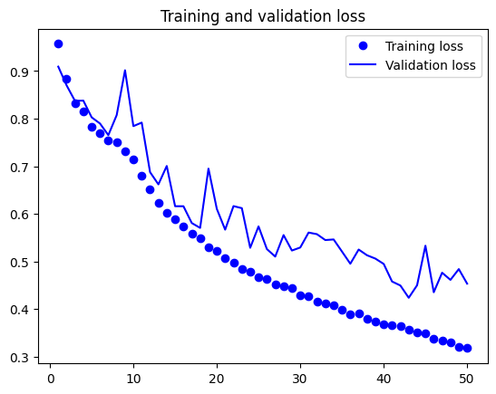

```python
epochs = range(1, len(history.history["loss"]) + 1)
loss = history.history["loss"]
val_loss = history.history["val_loss"]
plt.figure()
plt.plot(epochs, loss, "bo", label="Training loss")
plt.plot(epochs, val_loss, "b", label="Validation loss")
plt.title("Training and validation loss")
plt.legend()
```

[figure not shown]

```python
from tensorflow.keras.utils import array_to_img

model = keras.models.load_model("oxford_segmentation.keras")

i = 4
test_image = val_input_imgs[i]
plt.axis("off")
plt.imshow(array_to_img(test_image))
```

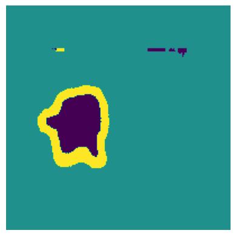

```python
mask = model.predict(np.expand_dims(test_image, 0))[0]

def display_mask(pred):
    mask = np.argmax(pred, axis=-1)
    mask *= 127
    plt.axis("off")
    plt.imshow(mask)

display_mask(mask)
```

```python
!jupyter nbconvert --to html chapter09_part01_image_segmentation.ipynb
```

```
[NbConvertApp] Converting notebook chapter09_part01_image_segmentation.ipynb to html
[NbConvertApp] Writing 1395677 bytes to chapter09_part01_image_segmentation.html
```